# MITB Capstone Project

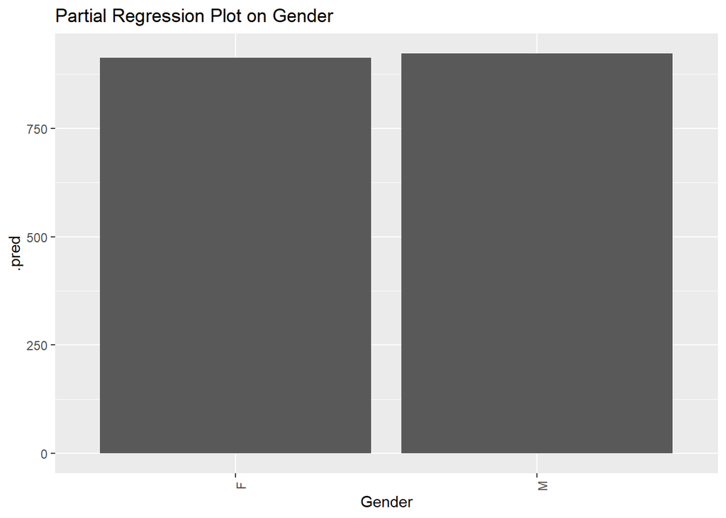

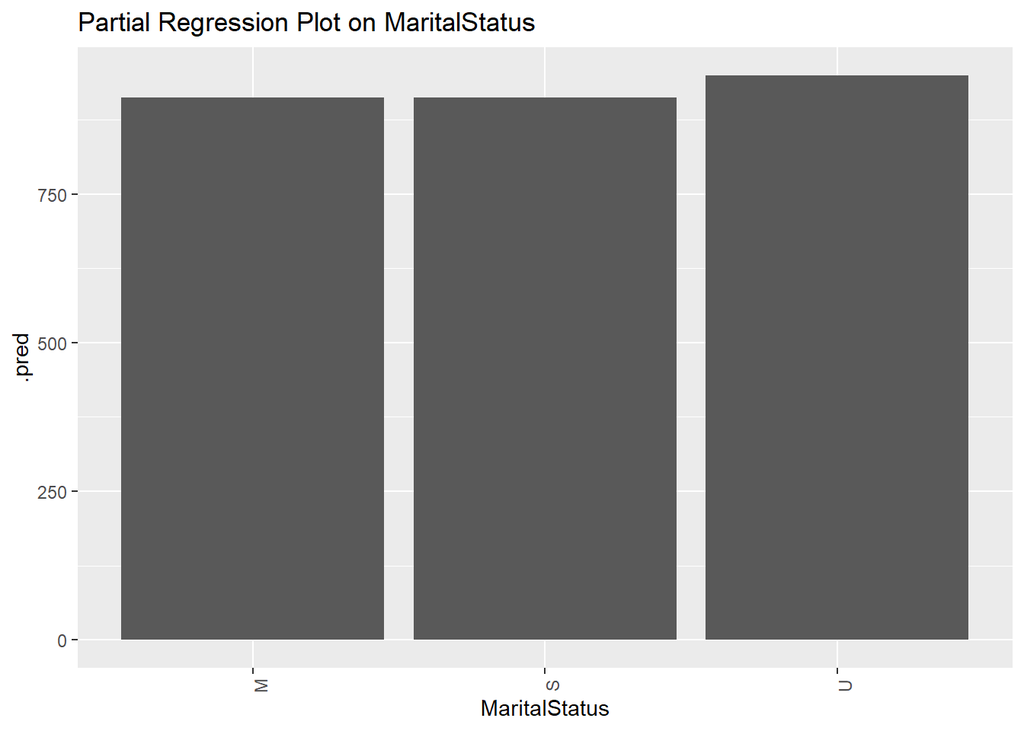

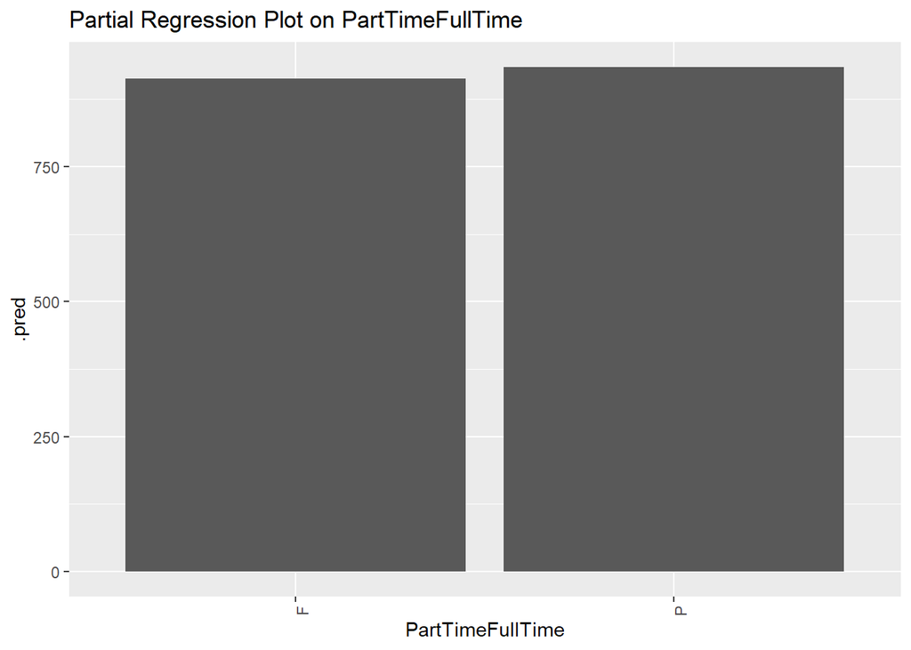

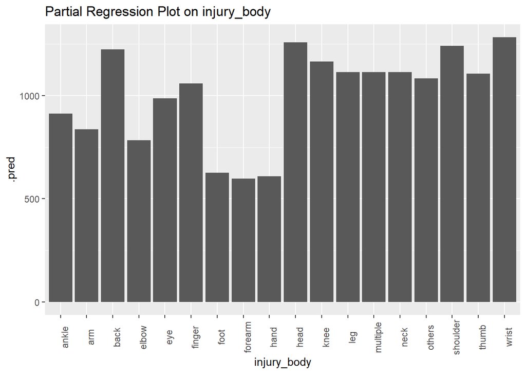

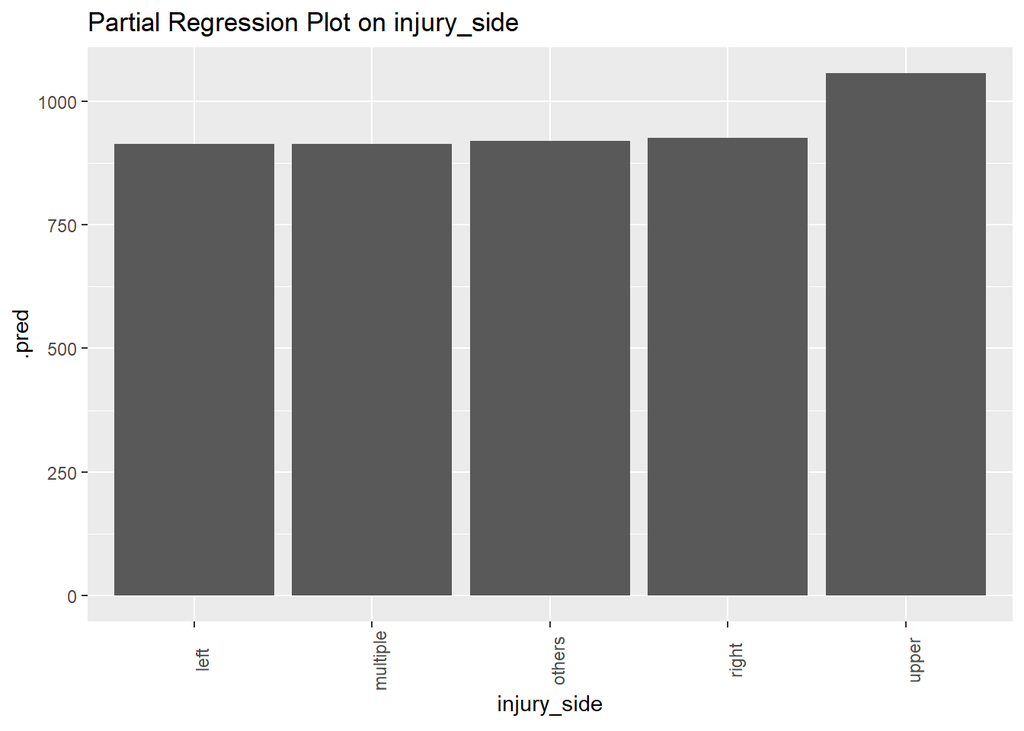

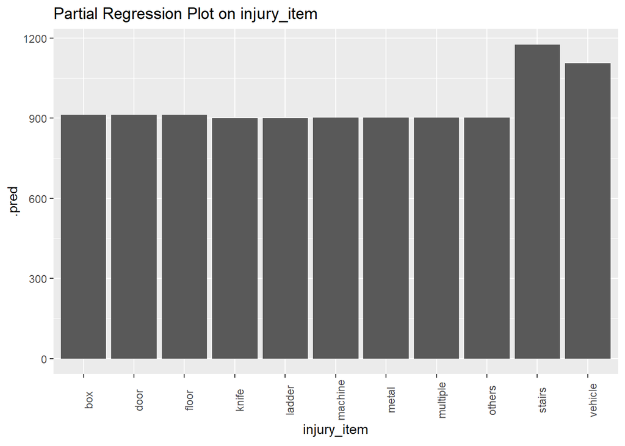

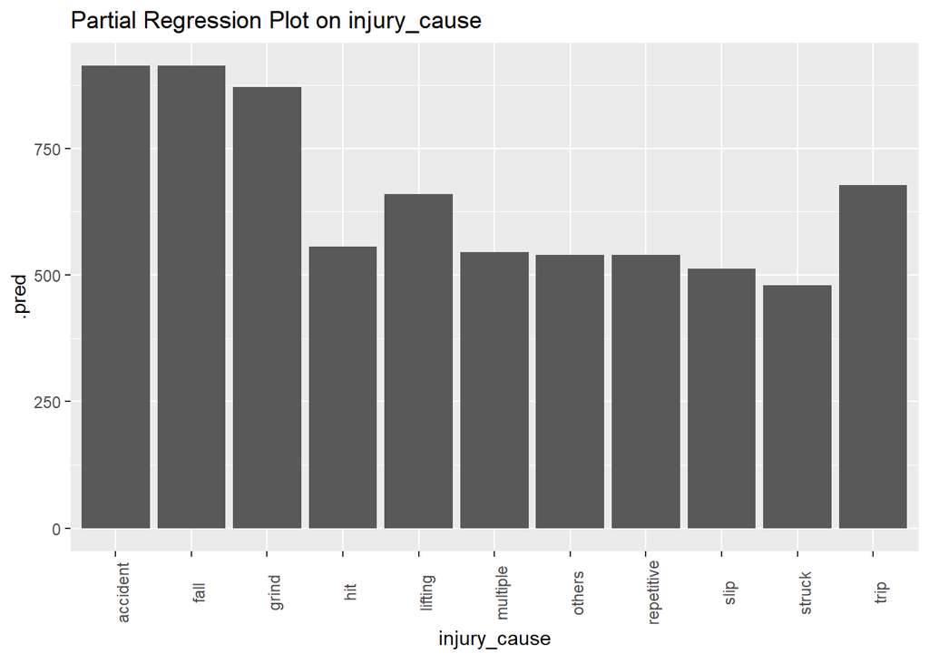

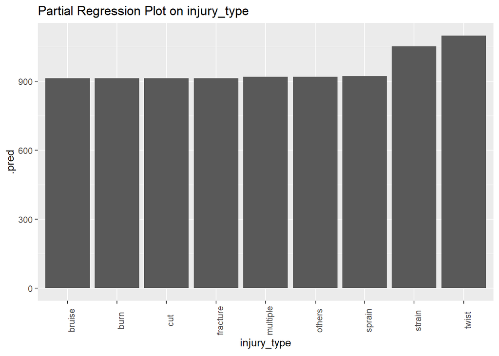

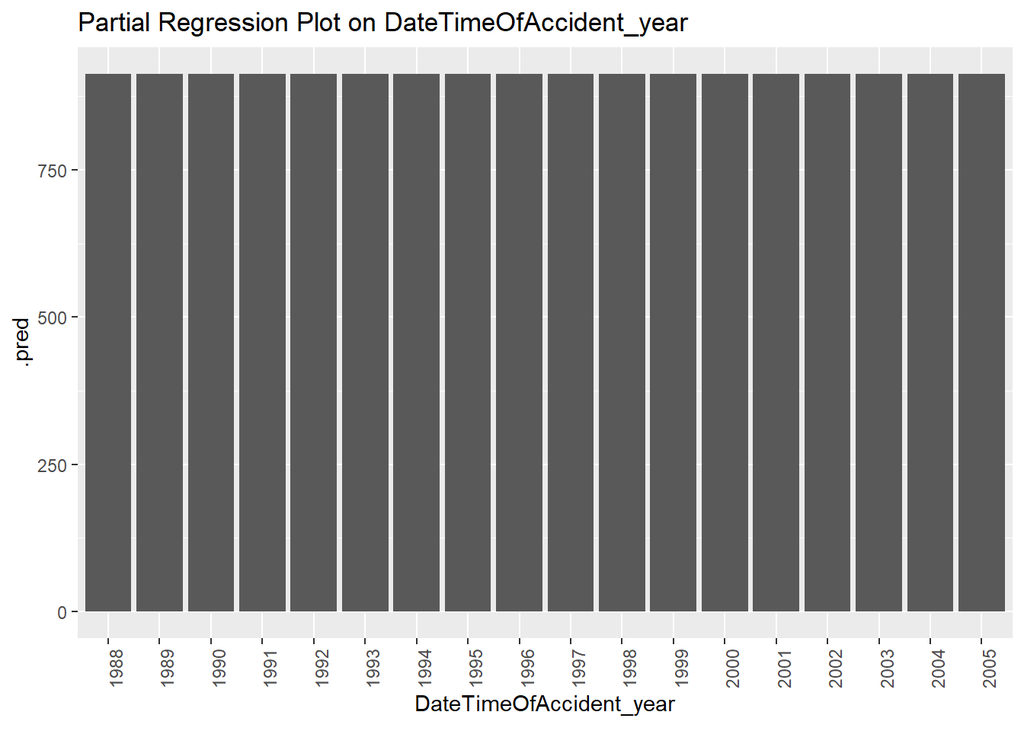

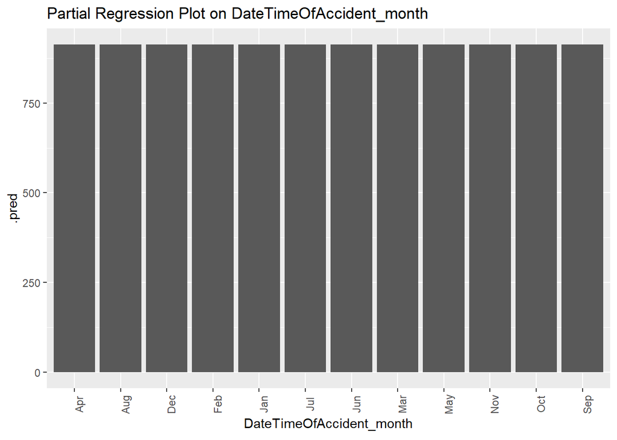

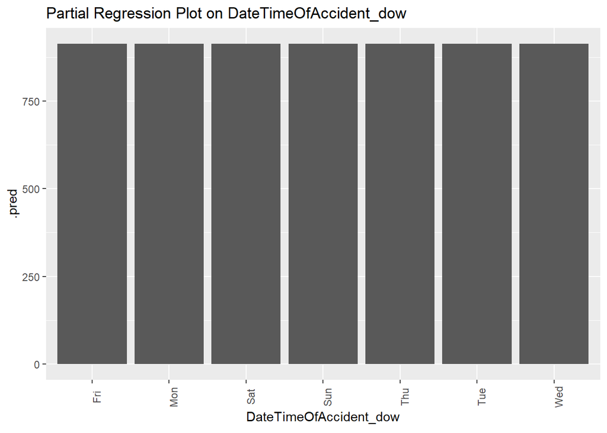

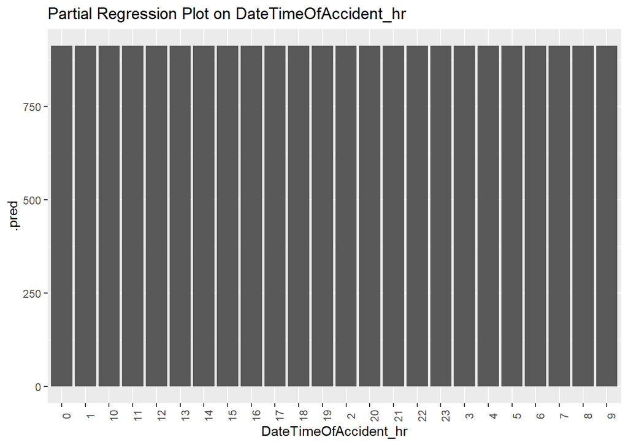

```r
for (i in cat_var_list){
  ranger_pdp <-
  recipe(init_ult_diff ~ ., data = df_train) %>%
  step_date(c(DateTimeOfAccident, DateReported)) %>%
  step_mutate(DateTimeOfAccident_hr = lubridate::hour(DateTimeOfAccident),
              DateTimeOfAccident_hr = factor(DateTimeOfAccident_hr, order = TRUE),
              DateTimeOfAccident_year = factor(DateTimeOfAccident_year, order = TRUE),
              DateReported_year = factor(DateReported_year, order = TRUE)) %>%
  step_profile(all_predictors(), -sym(i), profile = vars(i)) %>%
  prep() %>%
  juice()

  print(predict(ranger_fit_pdp, ranger_pdp) %>%
  bind_cols(ranger_pdp) %>%
  ggplot(aes(x = get(i), y = .pred)) +
    xlab(sym(i)) +
    labs(title = paste0("Partial Regression Plot on ", sym(i))) +
    theme(axis.text.x = element_text(angle = 90)) +
  geom_col()
  )
}
```

From the graph for num_week_paid_init, it seems like the predicted values are understated when the num_week_paid_init is shorter, overstated when the num_week_paid_init is long.

There seems to be some structural pattern within the graph. There is a sharp drop in 20 weeks. This is where I fit two sub models (one with weeks less than 20 & another one with weeks more than 20) to see whether this would improve the model accuracy.

## 3.5 Partial Dependence Plot

The issue with partial regression plot is that it only considers one combinations of variables while deriving the marginal effect. So, over here, I will use partial dependence plot.

Partial dependence plot measures the average marginal effect of the selected variable.

```r
pdp_pred_fun <- function(object, newdata) {
  predict(object, newdata, type = "numeric")$.pred
}

pdp_pred_fun_cat <- function(object, newdata) {
  predict(object, newdata)$.pred
}

ranger_pred <- pdp_pred_fun(ranger_fit_pdp, df_train)

ranger_pred_cat <- pdp_pred_fun_cat(ranger_fit_pdp, df_train)
```

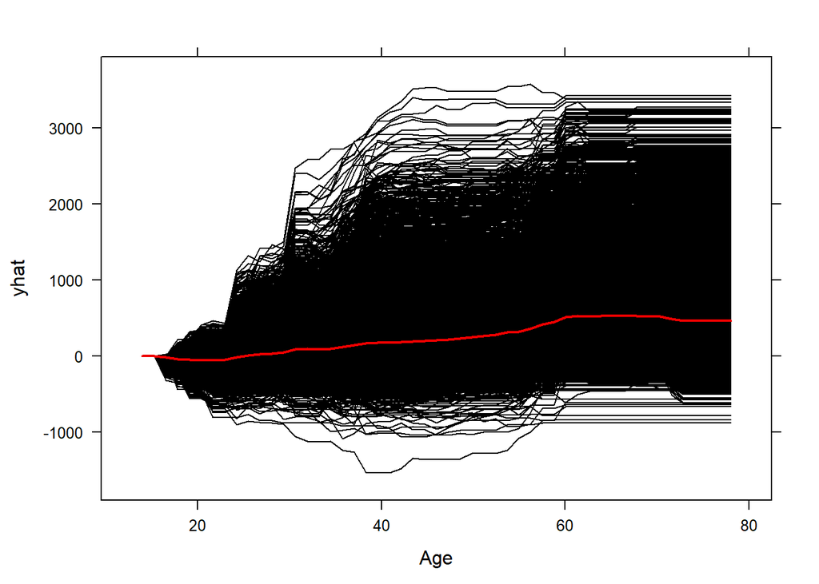

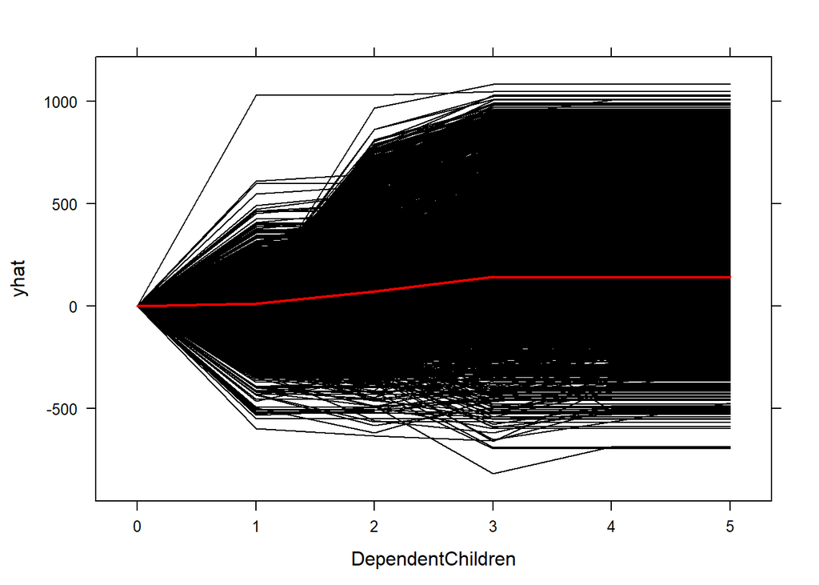

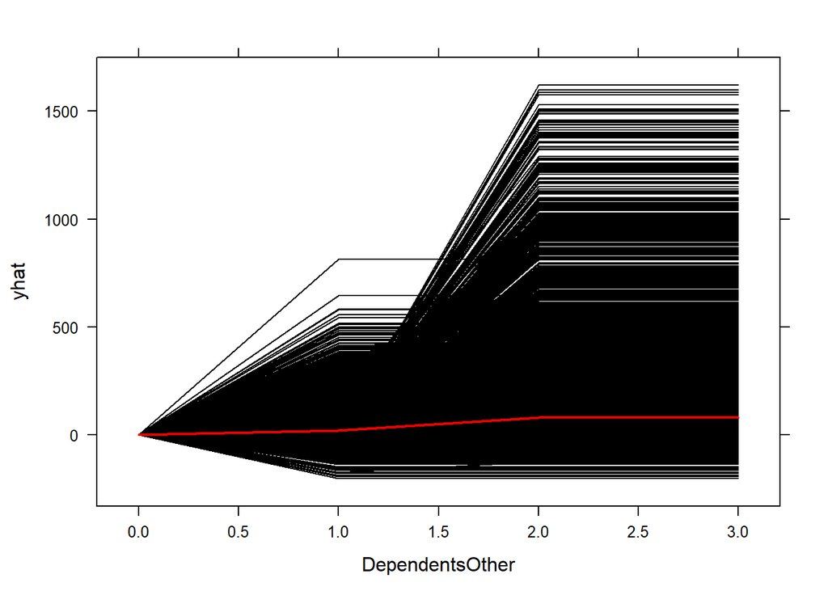

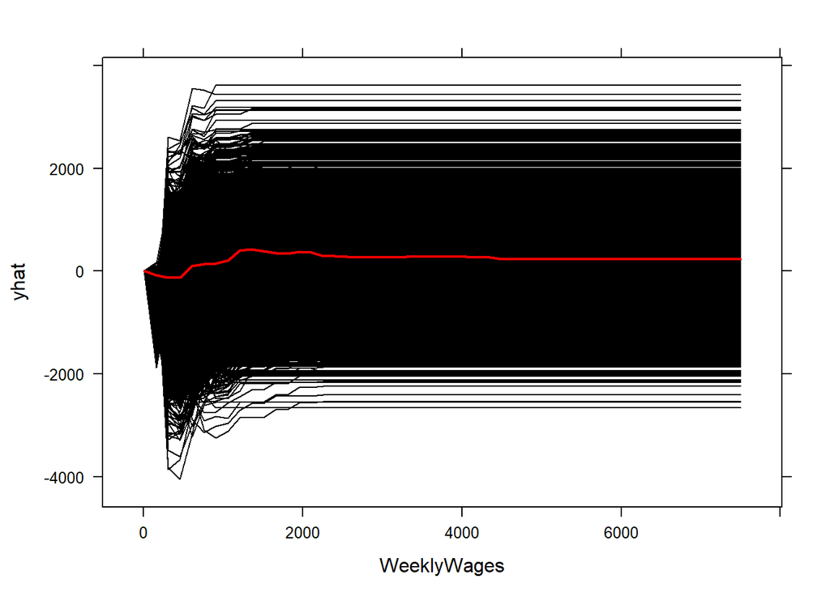

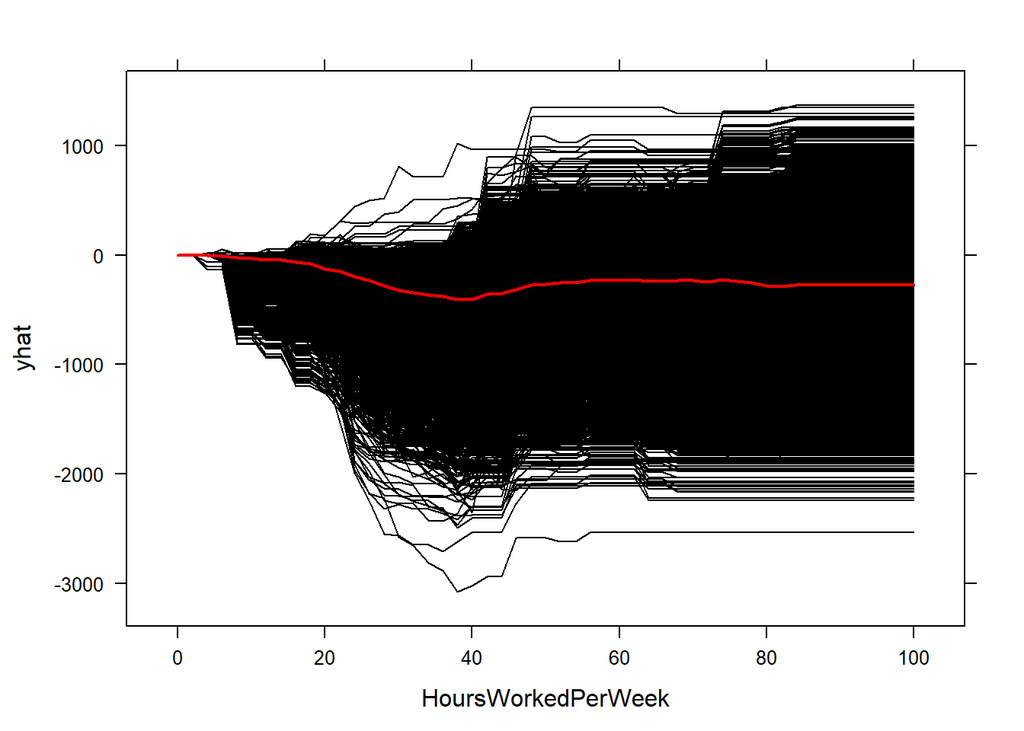

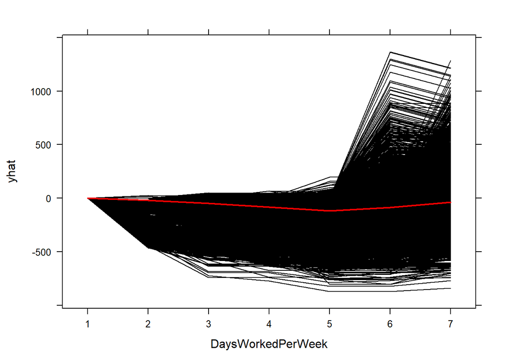

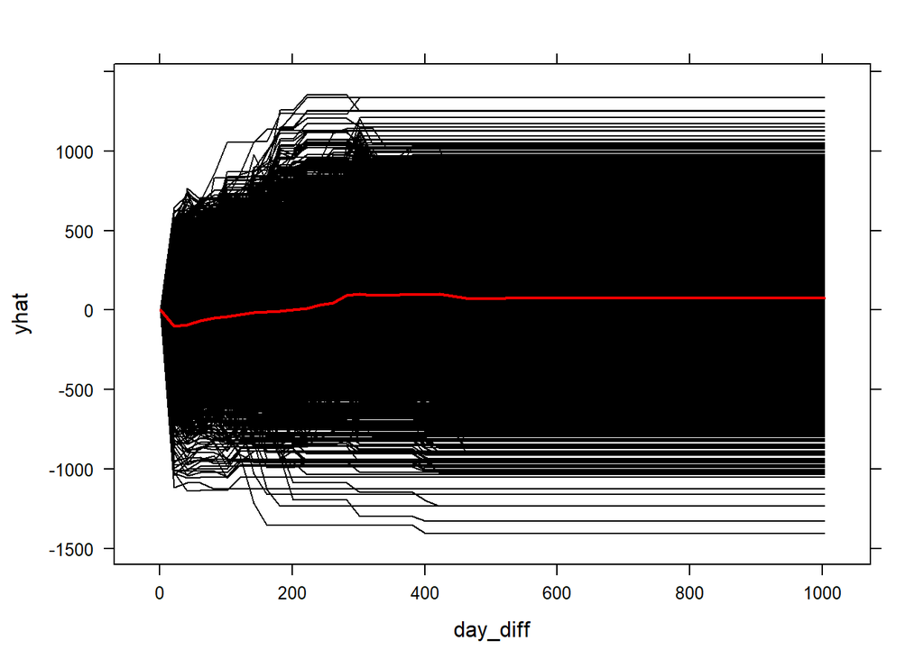

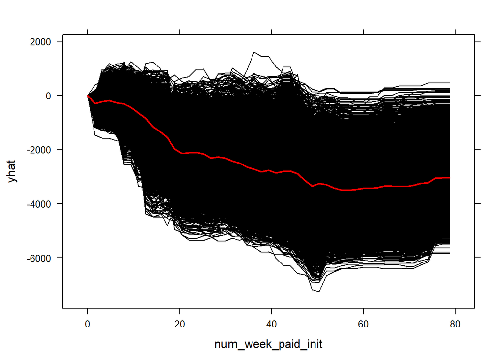

```r
for (i in num_var_list){
  assign(paste0("workflow_partial_" ,i),
  partial(ranger_fit_pdp,
          pred.var = i,
          ice = TRUE,
          center = TRUE,
          plot.engine = "ggplot2",
          pred.fun = pdp_pred_fun,
          train = df_train %>% dplyr::select(-init_ult_diff)))

  assign(paste0("graph_partial_", i),
         plotPartial(get(paste0("workflow_partial_" ,i))))

  print(get(paste0("graph_partial_", i)))

}
```

Note that the most of the partial dependence plots look different from those under partial regression plot. This is because the partial dependence plot permutates over different combinations and measure the marginal effect of the selected variable.

# Appendix

```r
#save.image(file = "data/MITBCapstone_machinelearn_actLoss_Jasper_v3.RData")
load(file = "data/MITBCapstone_machinelearn_actLoss_Jasper_v3.RData")
```